# Les Jeux paralympiques

Morghi Younesse

09/11/2021

Les Jeux paralympiques sont un événement sportif international majeur, regroupant les sports d’été ou d’hiver, auquel des milliers d’athlètes handicapés participent à travers différentes compétitions tous les quatre ans à la suite des Jeux olympiques, pour chaque olympiade. Y participent des athlètes atteints par un handicap physique, visuel ou mental. Ils sont organisés par le Comité international paralympique (et non pas par le Comité international olympique).

[figure not shown]

```r
#install.packages("tidyverse")
#install.packages("rvest")
#install.packages("skimr")
#gère différents types de données et renvoie un objet skim_df qui peut être inclus dans un pipeline tidyverse ou affiché de manière élégante pour le lecteur humain.
#install.packages("reshape2")
#Ce package permet surtout le remodelage des données. Ses deux principales fonctions sont la fonction melt, qui permet le passage d’un jeu de données de la mise en forme large à la mise en forme longue, et la fonction cast, qui permet de réaliser l’inverse.
#install.packages("gganimate")
#Ce package permet d’ajouter des animations aux graphiques statiques produits à l’aide de ggplot2
#install.packages("magick")
#Traitement Facile des Images dans R à l’Aide du Package Magick
#install.packages("maps")
#pour la cartographie
```

```r
# Chargement des données et des bibliothèques
library(tidyverse)
library(skimr)
library(knitr)
library(rvest)
library(reshape2)
library(gganimate)
library(magick)
library(maps)
SW <- readr::read_csv('https://raw.githubusercontent.com/youmrg/data_R/main/SW.csv')
```

#### le jeu des données

```r
SW
```

```
## # A tibble: 6,201 x 6
##    gender event               medal  athlete        abb    year
##    <chr>  <chr>               <chr>  <chr>          <chr> <dbl>
##  1 Men    25 m Freestyle 1A   Gold   KENNY Mike     GBR    1980
##  2 Men    25 m Freestyle 1A   Silver KANTOLA Pekka  FIN    1980
##  3 Men    25 m Freestyle 1A   Bronze TIETZE H.      FRG    1980
##  4 Men    25 m Freestyle 1B   Gold   BURGER M.      CAN    1980
##  5 Men    25 m Freestyle 1B   Silver SLUPE G.       USA    1980
##  6 Men    25 m Freestyle 1B   Bronze MAKI Eero      FIN    1980
##  7 Men    25 m Freestyle 1C   Gold   SMYK Zbigniew  POL    1980
##  8 Men    25 m Freestyle 1C   Silver EMMEL Manfred  FRG    1980
##  9 Men    25 m Freestyle 1C   Bronze OCKVIRK Robert USA    1980
## 10 Men    50 m Freestyle CP C Gold   ADLER Kare     NOR    1980
## # ... with 6,191 more rows
```

## Questions:

#### **1.Quel le classement des pays selon les nombre de medailles depuis le début des jeux ?

compter les medailles de chaque pays

```r
medal_count<- SW %>%
  group_by(abb, medal) %>%
  summarize(Count=length(medal))
medal_count
```

```
## # A tibble: 172 x 3
## # Groups:   abb [67]
##    abb   medal  Count
##    <chr> <chr>  <int>
##  1 ARG   Bronze     9
##  2 ARG   Gold       5
##  3 ARG   Silver    10
##  4 AUS   Bronze   160
##  5 AUS   Gold     147
##  6 AUS   Silver   158
##  7 AUT   Bronze     2
##  8 AUT   Gold       2
##  9 AUT   Silver     4
## 10 AZE   Gold       1
## # ... with 162 more rows
```

ordonner les pays par nombre de medailles

```r
ord_med <- medal_count %>%
  group_by(abb) %>%
  summarize(Total=sum(Count)) %>%
  arrange(Total) %>%
  select(abb)
  ord_med
```

```
## # A tibble: 67 x 1
##    abb
##    <chr>
##  1 BAH
##  2 BUL
##  3 KAZ
##  4 LTU
##  5 MAR
##  6 TTO
##  7 VIE
##  8 IPP
##  9 SLO
## 10 TCH
## # ... with 57 more rows
```

```r
medal_count$abb <- factor(medal_count$abb, levels=ord_med$abb)
```

le plot

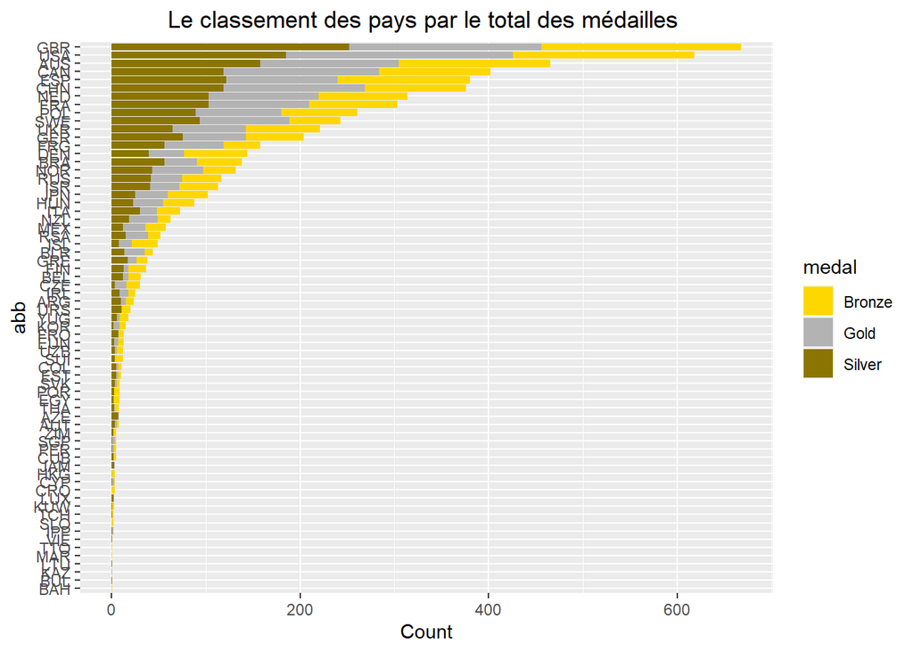

```r
ggplot(medal_count, aes(x=abb, y=Count, fill=medal)) +
  geom_col() +
  coord_flip() +
  scale_fill_manual(values=c("gold1","gray70","gold4")) +
  ggtitle("Le classement des pays par le total des médailles ") +
  theme(plot.title = element_text(hjust = 0.5))
```

#### **2.Quel le Nombre de medailles d’or de la France au fil du temps?

```r
FR_gold <- SW %>% group_by(year, abb, medal) %>% filter(medal=="Gold", abb=='FRA') %>% summarize(Count=n()) %>% arrange(year) %>% group_by(year)
FR_gold
```

```
## # A tibble: 9 x 4
## # Groups:   year [9]
##    year abb   medal Count
##   <dbl> <chr> <chr> <int>
## 1  1980 FRA   Gold      4
## 2  1984 FRA   Gold     35
## 3  1988 FRA   Gold     16
## 4  1992 FRA   Gold     20
## 5  1996 FRA   Gold     12
## 6  2000 FRA   Gold     12
## 7  2004 FRA   Gold      4
## 8  2008 FRA   Gold      2
## 9  2012 FRA   Gold      2
```

Le plot :

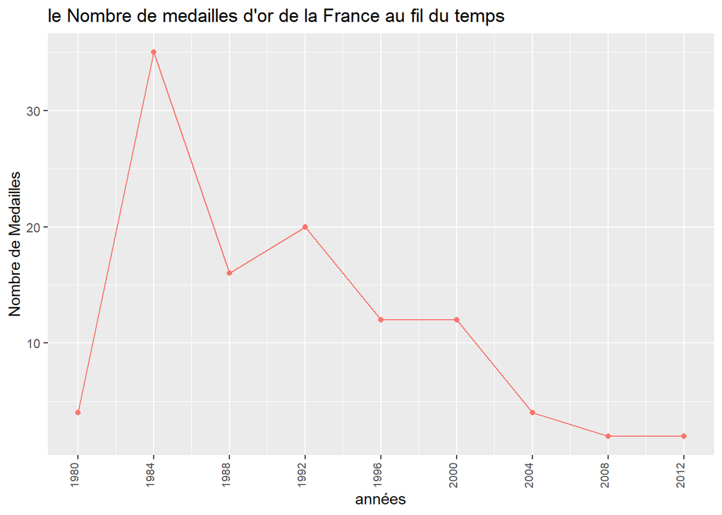

```r
ggplot(FR_gold, aes(x=year, y=Count, group=medal)) +
geom_line(aes(colour=abb)) +
geom_point(aes(colour=abb))+
scale_x_continuous(breaks=FR_gold$year)+
theme(legend.position="none", legend.text=element_text(size=0),axis.text.x=element_text(size=8, angle=90,vjust=0,hjust=1))+
labs(title="le Nombre de medailles d'or de la France au fil du temps", x="années", y="Nombre de Medailles")
```

#### **3.quel est le nombre de medailles par sex ?

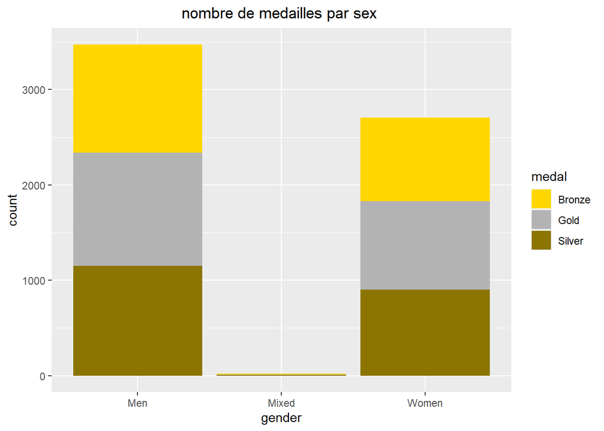

```r
ggplot(SW,aes(x= gender ,fill= medal))+
  geom_bar()+
  scale_fill_manual(values=c("gold1","gray70","gold4")) +
  ggtitle("nombre de medailles par sex ") +
  theme(plot.title = element_text(hjust = 0.5))
```

#### **4.quel est le nombre de medailles par sex pour chaque année ?

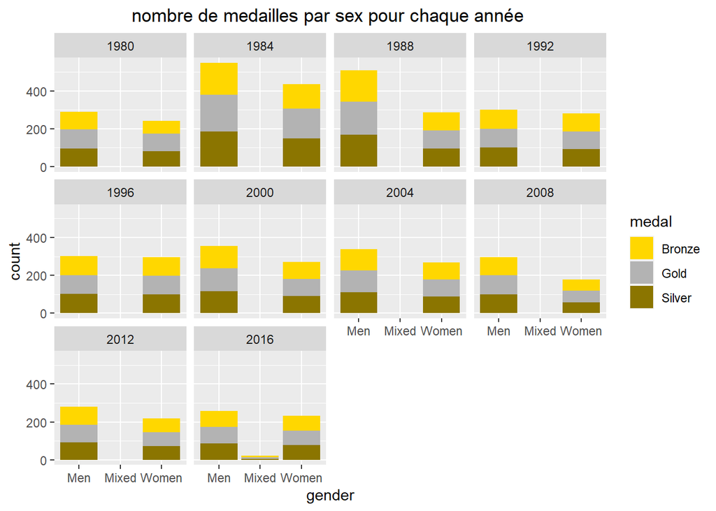

```r
ggplot(SW,aes(x= gender ,fill= medal))+
  facet_wrap(~ year)+
  geom_bar()+
  scale_fill_manual(values=c("gold1","gray70","gold4")) +
  ggtitle("nombre de medailles par sex pour chaque année ") +
  theme(plot.title = element_text(hjust = 0.5))
```

#### **5.Quel Le nombre des hommes et des femmes au fil des années?

Tableau de comptage du nombre d’athlètes par année et sexe:

```r
counts_sex <- SW %>%
   filter(gender != "Mixed")%>%
group_by(year,gender) %>%
  summarize(Athletes = length(unique(athlete)))
counts_sex$year <- as.integer(counts_sex$year)
counts_sex
```

```
## # A tibble: 20 x 3
## # Groups:   year [10]
##     year gender Athletes
##    <int> <chr>     <int>
##  1  1980 Men         118
##  2  1980 Women        92
##  3  1984 Men         214
##  4  1984 Women       144
##  5  1988 Men         185
##  6  1988 Women        97
##  7  1992 Men         121
##  8  1992 Women       106
##  9  1996 Men         136
## 10  1996 Women       115
## 11  2000 Men         176
## 12  2000 Women       118
## 13  2004 Men         151
## 14  2004 Women       110
## 15  2008 Men         128
## 16  2008 Women        86
## 17  2012 Men         133
## 18  2012 Women        96
## 19  2016 Men         131
## 20  2016 Women       111
```

Le plot:

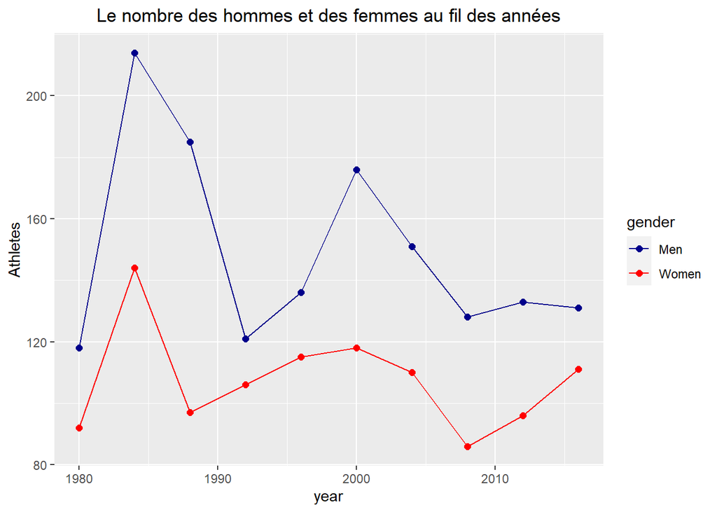

```r
ggplot(counts_sex, aes(x=year, y=Athletes, group=gender, color=gender)) +
  geom_point(size=2) +
  geom_line()  +
  scale_color_manual(values=c("darkblue","red")) +
  labs(title = "Le nombre des hommes et des femmes au fil des années") +
  theme(plot.title = element_text(hjust = 0.5))
```